# R-Ladies + Lingwars: Taller de minería de textos con R

R-Ladies Madrid, Verónica García y Claudia Guirao, 17/10/2017

## ¿Quiénes somos?

- **Verónica García**, @yryaa
- **Claudia Guirao**, @claudiaguirao

RLadies y Data Scientists en **Kernel Analytics**

Código y datos en https://github.com/intiveda/rladies_textmining

## Text Mining

Gran parte de los datos se encuentran no estructurados, es importante conocer técnicas que nos permitan obtener conclusiones a partir de los mensajes que generan nuestras organizaciones, clientes, usuarios o internet en general

## Materiales y librerías

- Subtítulos temporadas de los Simpsons
- Librerías: `tm, tidytext, tidyverse, dplyr, datatable, ggplot, igraph, ggraph, worldcloud`

## Back2basics: Strings y expresiones regulares

Las cadenas o strings cumplen un papel importante en las tareas de ETL o preparación de los datos. Una de las librerías esenciales en la materia es **string**

String es uno de los paquetes diseñados por Hadley Wickham para asistir en las tareas de manipulación de strings:

- se integra con *pipes* (%<%)
- sus funciones son consistentes y fáciles de interpretar

### ¿Qué son las cadenas de texto o *strings*?

- Las cadenas de texto se encuentran contenidas entre comillas `""` (*usar la comilla simple `'` para escapar la doble comilla)
- Pueden contener letras `"a"`, números `"1"`, simbolos `"&"` o todo lo anterior `"1a&"`
- Mientras que los números puede ser a la vez *integers* y *characters*, las letras y los s?mbolos no tienen significado como integer y se traducen en `NA`

```r
as.integer(c("a", "&", "123"))
```

```
[1]  NA  NA 123
```

```r
c(factor("a"), "b", "&",1)
```

```
[1] "1" "b" "&" "1"
```

Concatenar integers y characters, convierte automáticamente los integers en *characters*.

```r
c(as.character(factor("a")), "b", "&",1)
```

```
[1] "a" "b" "&" "1"
```

### Operaciones básicas

#### Operadores

Muchas de estas funciones tienne su equivalente en R base, pueden ser más lentas/menos eficientes

- `str_to_upper(string)`: convierte un string en mayúsculas
- `str_to_lower(string)`: convierte un string en minúsculas
- `str_to_title(string)`: capitaliza un string

```r
str_to_upper(temas)
```

```
 [1] "CÓDIGO"        "MUJERES"       "TECNOLOGÍA"    "INFORMÁTICA"   "ESTADÍSTICA"   "WOMEN"         "CODERS"        "APRENDIZAJE"   "AUTOMÁTICO"    "ANÁLISIS"      "DATOS"         "VISUALIZACIÓN"
[13] "R-LADIES"      "SOCIAL"        "CODING"        "R"             "CIENCIA"       "PROGRAMMING"
```

```r
str_to_lower(temas)
```

```
 [1] "código"        "mujeres"       "tecnología"    "informática"   "estadística"   "women"         "coders"        "aprendizaje"   "automático"    "análisis"      "datos"         "visualización"
[13] "r-ladies"      "social"        "coding"        "r"             "ciencia"       "programming"
```

```r
str_to_title(temas)
```

```
 [1] "Código"        "Mujeres"       "Tecnología"    "Informática"   "Estadística"   "Women"         "Coders"        "Aprendizaje"   "Automático"    "Análisis"      "Datos"         "Visualización"
[13] "R-Ladies"      "Social"        "Coding"        "R"             "Ciencia"       "Programming"
```

- `str_c(string, sep = "")`: junta varios string en uno solo, es el equivalente a `paste(sep = "")` o `paste0()`
- `str_length(string)`: devuelve la longitud del string, es similar a la función `nchar()`. Convierte los factores en strings y conserva los NA’s

```r
print(str_length('R-Ladies'))
print(str_length(NA))
```

[output not shown]

- `str_sub(string, start, end)`: subsetea un string o un vector de string especificando la posición inicial y la final, es el equivalente en R base a substr(). Por defecto finaliza en el último caracter.

```r
str_sub(string = temas[1:4], start=3)
```

```
[1] "digo"      "jeres"     "cnología"  "formática"
```

- `str_dup(string, times)`: copia y pega un string un número determinado de veces

```r
str_dup(string = temas[1:4], times = 3)
```

```
[1] "CódigoCódigoCódigo"                "MujeresMujeresMujeres"             "tecnologíatecnologíatecnología"    "InformáticaInformáticaInformática"
```

- `str_trim(string, side = c("both", "left", "rigth"))`: elimina los espacios vacíos, por defecto toma el valor *both*. Mejor evitar `gsub(" ", "", string)`
- `str_pad(string, width, side = c("left", "both", "right"), pad = " "))`: añade a strings espacios en blanco para igualarlos en longitud, especialmente útil para añadir 0 a números.

### Expresiones regulares

Las expresiones regulares ( *regular expressions*, *regex*, *pattern matching*) son un lenguaje usado para parsear y manipular texto. Se usan comúnmente para hacer operaciones de búsqueda y reemplazo y para validar si un texto está bien formado.

##### Expresiones comunes

- “a” = letra “a”
- “^a” = empieza con la letra “a”
- “a$” = finaliza con la letra “a”
- “[ ]” = contiene cualquier letra (o número) de las contenidas en los corchetes
- “[ - ]” = contiene cualquier letra (o número) dentro de un rango
- “[^ae]” = cualquier cosa excepto determinadas letras (o números)
- “{3}” = repite la expresión regular 3 veces

Las expresiones regulares son un mundo en si mismo, aquí tienes una pequeña *chuleta* : https://www.rstudio.com/wp-content/uploads/2016/09/RegExCheatsheet.pdf

```r
rcosas = c("baseR", "R-Ladies", "Rmeetup", "Rmarkdown", "stringR")
str_detect(rcosas, pattern = "^R")
```

```
[1] FALSE  TRUE  TRUE  TRUE FALSE
```

```r
rcosas[str_detect(rcosas, pattern = "^R")]
```

```
[1] "R-Ladies"  "Rmeetup"   "Rmarkdown"
```

```r
rcosas[str_detect(rcosas, pattern = "R")]
```

```
[1] "baseR"     "R-Ladies"  "Rmeetup"   "Rmarkdown" "stringR"
```

```r
cleancode <- c("tidyverse", "tidyr","dplyr", "ggplot2", "tidytext", "purrr")
str_locate(cleancode, "tidy")
```

```
     start end
[1,]     1   4
[2,]     1   4
[3,]    NA  NA
[4,]    NA  NA
[5,]     1   4
[6,]    NA  NA
```

##### Otras funciones

- `str_extract(string, pattern)` o `str_extract_all()`: busca la palabra exacta (normalmente se utiliza con expresiones regulares concatenadas)
- `str_match(string, pattern)` o `str_match_all()`: es una función equivalente pero devuelve una matriz

```r
str_match(c("12345678", "12587465", "dni desconocido"), pattern = "[1-9]{8}")
```

```
     [,1]
[1,] "12345678"
[2,] "12587465"
[3,] NA
```

```r
str_match_all(c("12345678", "12587465", "dni desconocido"), pattern = "[1-9]{8}")
```

```
[[1]]
     [,1]
[1,] "12345678"

[[2]]
     [,1]
[1,] "12587465"

[[3]]
     [,1]
```

- `str_replace(string, pattern, replacement)`: reemplaza la primera instancia, `str_replace_all` para reemplazarlas todas

```r
str_replace(c("castanya", "otonyo", "veronyo", "anyo", "nyonyo"), pattern = "ny", replacement = "ñ")
```

```
[1] "castaña" "otoño"   "veroño"  "año"     "ñonyo"
```

```r
str_replace_all(c("castanya", "otonyo", "veronyo", "anyo", "nyonyo"), pattern = "ny", replacement = "ñ")
```

```
[1] "castaña" "otoño"   "veroño"  "año"     "ñoño"
```

- `str_split(string, pattern)`: separa una cadena en un vector, `str_split_fixed(string, pattern, n)` lo hace en un número `n` determinado de elementos

```r
print(str_split("Eres muy chu chu chuli",pattern = " "))
```

```
[[1]]
[1] "Eres"  "muy"   "chu"   "chu"   "chuli"
```

```r
print(length(str_split("Eres muy chu chu chuli",pattern = " ")[[1]]))
```

```
[1] 5
```

## Analizando texto con R: los Simpsons fuente de sabiduría

```r
library(subtools)
a <- read.subtitles.serie(dir = "C:/Users/ClaudiaG/Documents/rladies/rladies_repo/rladies_textmining/The Simpsons/")
```

```
Read: 6 seasons, 130 episodes
```

```r
df <- subDataFrame(a)
df <- df[complete.cases(df), ]
str(df)
```

```
'data.frame':   35517 obs. of  8 variables:
 $ ID          : chr  "1" "2" "3" "4" ...
 $ Timecode.in : chr  "00:00:00.042" "00:00:08.759" "00:00:10.761" "00:00:15.557" ...
 $ Timecode.out: chr  "00:00:00.042" "00:00:10.677" "00:00:13.180" "00:00:17.851" ...
 $ Text        : chr  "23.976" "Ooh! Careful, Homer!" "There's no time. We're late." "O little town of Bethlehem" ...
 $ season      : chr  "season 1" "season 1" "season 1" "season 1" ...
 $ season_num  : num  1 1 1 1 1 1 1 1 1 1 ...
 $ episode_num : num  1 1 1 1 1 1 1 1 1 1 ...
 $ serie       : chr  "The Simpsons" "The Simpsons" "The Simpsons" "The Simpsons" ...
```

```r
library(tm)
c <- tmCorpus(a)
c <- tm_map(c, content_transformer(tolower))
c <- tm_map(c, removePunctuation)
c <- tm_map(c, removeNumbers)
c <- tm_map(c, removeWords, stopwords("english"))
c <- tm_map(c, stripWhitespace)
```

```r
# unique(as.data.table(df[, c("season_num", "episode_num")]))[,"season_num"]
# TDM <- TDM[,1:length(vec.season$season_num)]
TDM.season <- t(apply(TDM, 1, function(x) tapply(x, vec.season$season_num, sum)))
```

[output not shown]

[figure not shown]

```r
library(tidytext)
library(tidyverse)
data(stop_words)
tidy_df <- df %>%
  unnest_tokens(word, Text) %>%
  dplyr::anti_join(stop_words)
```

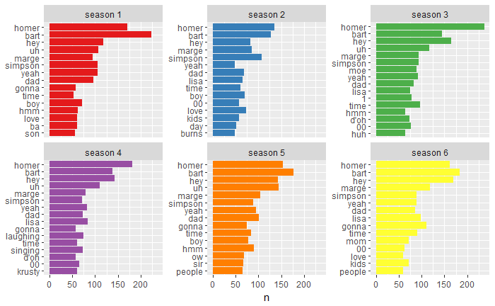

```r
library(dplyr)
library(ggplot2)
tidy_df %>% group_by(season) %>%
        count(word, sort = TRUE) %>%
        top_n(15) %>%
        ggplot(aes(reorder(word,n), n, fill = season)) +
        geom_col() +
        coord_flip() +
        facet_wrap(~season, scales = "free_y") +
        labs(x = NULL) +
        guides(fill = FALSE) +
        scale_fill_brewer(palette = "Set1")
```

[figure not shown]

[figure not shown]

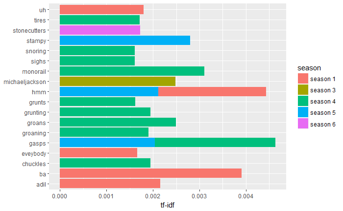

```r
tf_idf_df %>%
  top_n(20) %>%
  ggplot(aes(word, tf_idf, fill = season)) +
  geom_col() +
  labs(x = NULL, y = "tf-idf") +
  coord_flip()
```

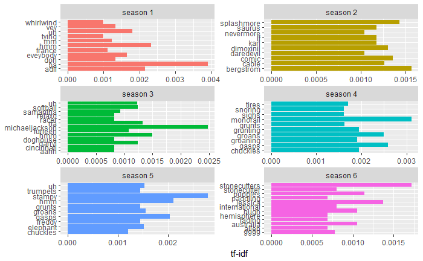

```r
tf_idf_df %>%
  group_by(season) %>%
  top_n(10) %>%
  ungroup %>%
  ggplot(aes(word, tf_idf, fill = season)) +
  geom_col(show.legend = FALSE) +
  labs(x = NULL, y = "tf-idf") +
  facet_wrap(~season, ncol = 2, scales = "free") +
  coord_flip()
```

## Anexos y otra információn útil

- http://www.pieceofk.fr/?p=437
- https://rstudio-pubs-static.s3.amazonaws.com/180610_d3764c43f1e54692b7e84d21ec94772a.html
- http://tamaszilagyi.com/blog/a-tidy-text-analysis-of-rick-and-morty/